# Linear (Matrix) Transformations

A function is a mapping from a set of elements called the domain into a second set of elements called the codomain. Often we think of these as applying to real numbers.

e.g. $ x\rightarrow e^x$ etc.

More generally we might write: $f(x) = y$

When we look at individual values we say that for $a$, which is an element of the domain, then $f(a)=b$ is an element of the codomain which is the image $a$ under the function $f(.)$.

When we consider the set of all values of the domain going into $f(.)$ and the set of all resulting values in the codomain, we refer to the the image of the function. Sometimes the codomain and the image are the same sets, but not always (it depends on how the codomain is defined).

Example: Let a function $f$ be defined as $f: \mathbb{N}\rightarrow \mathbb{N}$ where $f(x)=x^2$.

In our case, we will consider transformations of vector spaces from $\mathbb{R}^n \rightarrow \mathbb{R}^m$, with domain $A$ and codomain $B$ which are vector spaces.

We will generally denote such transformations as $T_a: \mathbb{R}^n\rightarrow \mathbb{R}^m$.

Linear transformations in this context take the form: $$ A\mathbf x=\mathbf b $$ where $\mathbf x\in \mathbb{R}^n$ and $A$ is an $m\times n$ **standard matrix** of the transformation. Clearly, $\mathbf b\in \mathbb{R}^m$.

Of course, it could be that $n=m$ but it does not have to. In the special case of $n=m$ we can call $T_a:$ an operator rather than a transformation. NB: Despite this, we will use transformation for both cases.

Example 7.1

$$ T_a: \mathbb{R}^3 \rightarrow \mathbb{R}^2 \mbox{ given by } T_a(x_1,x_2,x_3)=(x_1+x_2,\ x_2+x_3) $$

In such a case we get the following standard matrix:

$$ \begin{bmatrix} 1 & 1 & 0\\ 0 & 1 & 1 \end{bmatrix} $$

Try using $\mathbf x=(1,2,3)$

Example of a non-linear transformation

$$ T_a: \mathbb{R}^3 \rightarrow \mathbb{R}^2 \mbox{ given by } T_a(x_1,x_2,x_3)=(x_1^2+x_2,\ x_1+x_2+x_3) $$

In such a case we get the following standard matrix:

$$ \begin{bmatrix} x_1 & 1 & 0\\ 1 & 1 & 1 \end{bmatrix} $$

Notice that the variable $x_1$ must appear in the standard matrix, which is not allowed for linear transformations.

Definition: A matrix transformation (operator) of $\mathbb{R}^n\rightarrow \mathbb{R}^m$ is one that can be represented by the following equations: $$ b_1 = a_{11}x_1 + a_{12}x_2 + \ldots + a_{1n}x_n\\ \\ b_2 = a_{21}x_1 + a_{22}x_2 + \ldots + a_{2n}x_n\\ \vdots\\ b_m = a_{m1}x_1 + a_{m2}x_2 + \ldots + a_{mn}x_n $$

where vector $x=(x_1, x_2, \ldots,x_n)$ and for real constant values $a_{ij}$, giving the form:

$$ T_A: \qquad A\mathbf{x}=\mathbf{b} $$

and the transformation can be called the multiplication by $A$. Note the use of $A$ instead of $a$ to emphasize the use of the matrix $A$.

Theorem 4.9.1 [A&R] The Fundamental Properties of Linear Transformations.

Let $T_A(\mathbf x)=A\mathbf x$.

$$ \begin{align*} & T_A(k\mathbf x) = k T_A(\mathbf x) \\ \\ & T_A(\mathbf x + \mathbf y) = T_A(\mathbf x)+ T_A(\mathbf y) \end{align*} $$

Proof: From the properties of matrix/vector multiplication and addition.

Example 7.1. continued...

Check the fundamental properties to determine if the following transformations are linear.

1. $T_a: \mathbb{R}^3 \rightarrow \mathbb{R}^2 \mbox{ given by } T_a(x_1,x_2,x_3)=(x_1+x_2,\ x_2+x_3) $
2. $T_a: \mathbb{R}^3 \rightarrow \mathbb{R}^2 \mbox{ given by } T_a(x_1,x_2,x_3)=(x_1^2+x_2,\ x_1+x_2+x_3) $

Theorem 4.9.2

If $T_A(\mathbf x) = T_B(\mathbf x)$ then $A=B$

Examples 7.2

For each of the following cases, state the domain, codomain and standard matrix for the transformations specified by the defining equations and find the image of the vector $\mathbf x$ given. In each case, also determine whether the transformation is linear or not.

$$ \begin{align*} &(a)& \qquad T(x_1,\ x_2,\ x_3) \rightarrow (2x_1-3x_2+5x_3,\ 2x_1x_2-7x_3), \qquad\mathbf x=(1,2,4)\\ \\ &(b)& \qquad T(x_1,\ x_2,\ x_3) \rightarrow (x_1-3x_2x_3,\ 4x_1-6x_2+3x_3), \qquad\mathbf x=(0,2,-2)\\ \\ &(c)& \qquad T(x_1,\ x_2,\ x_3) \rightarrow (5x_1-x_2+x_3,\ -x_1+x_2+7x_3,\ 2x_1-4x_2-x_3), \qquad\mathbf x=(1,2,4)\\ \\ &(d)& \qquad T(x_1,\ x_2,\ x_3, \ x_4) \rightarrow (x_1^2-3x_2+x_2x_4,\ 3x_1-4x_2-x_3^2+x_4), \qquad\mathbf x=(1,2,4,-1)\\ \end{align*} $$

## Some Transformations in $\mathbb{R}^2$ and $\mathbb{R}^3$

#### **Orthonogal Reflections**

#### About the y-axis

$$ T_a: \mathbb{R}^2 \rightarrow \mathbb{R}^2 \mbox{ given by } T_a(x_1,x_2)=(-x_1,\ x_2)\\ \\ A=\begin{bmatrix} -1 & 0\\ 0 & 1 \end{bmatrix} $$

E.G. $(4,2)\rightarrow (-4,2)$

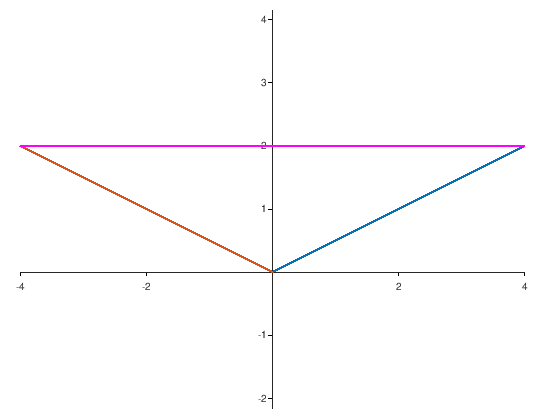

```matlab
graphics_toolkit ("gnuplot");
set(gca, "xaxislocation", "origin")
set(gca, "yaxislocation", "origin")
axis("equal")
x=[4 ;2 ];
A=[-1 0; 0 1];
v=A*x;
vec=x;
line([0,vec(1)],[0,vec(2)],"linewidth",4);
vec=v;
line([0,vec(1)],[0,vec(2)],"linewidth",4);
line([x(1),vec(1)],[x(2),vec(2)],"linewidth",4,"color","m");
```

#### About the x-axis

$$ T_a: \mathbb{R}^2 \rightarrow \mathbb{R}^2 \mbox{ given by } T_a(x_1,x_2)=(x_1,\ -x_2)\\ \\ A=\begin{bmatrix} 1 & 0\\ 0 & -1 \end{bmatrix} $$

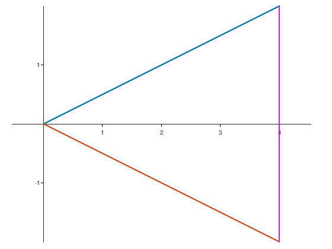

```matlab
graphics_toolkit ("gnuplot");
set(gca, "xaxislocation", "origin")
set(gca, "yaxislocation", "origin")
axis("equal")
x=[4 ;2 ];
A=[1 0; 0 -1];
v=A*x;
vec=x;
line([0,vec(1)],[0,vec(2)],"linewidth",4);
vec=v;
line([0,vec(1)],[0,vec(2)],"linewidth",4);
line([x(1),vec(1)],[x(2),vec(2)],"linewidth",4,"color","m");
```

#### About the x=y line

$$ T_a: \mathbb{R}^2 \rightarrow \mathbb{R}^2 \mbox{ given by } T_a(x_1,x_2)=(x_2,\ x_1)\\ \\ A=\begin{bmatrix} 0 & 1\\ 1 & 0 \end{bmatrix} $$

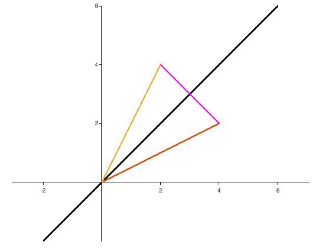

```matlab
graphics_toolkit ("gnuplot");
set(gca, "xaxislocation", "origin")
set(gca, "yaxislocation", "origin")
axis("equal")
line([-2,6],[-2,6],"linewidth",4,"color","k")
x=[4 ;2 ];
A=[0 1; 1 0];
v=A*x;
vec=x;
line([0,vec(1)],[0,vec(2)],"linewidth",4);
vec=v;
line([0,vec(1)],[0,vec(2)],"linewidth",4);
line([x(1),vec(1)],[x(2),vec(2)],"linewidth",4,"color","m");
```

#### About the xy plane

$$ T_a: \mathbb{R}^3 \rightarrow \mathbb{R}^3 \mbox{ given by } T_a(x_1,x_2,x_3)=(x_1,x_2,-x_3)\\ \\ A=\begin{bmatrix} 1 & 0 & 0\\ 0 & 1 & 0\\ 0 & 0 & -1 \end{bmatrix} $$

e.g. what would this transformation do to the vector $\mathbf x=(2,2,4)$?

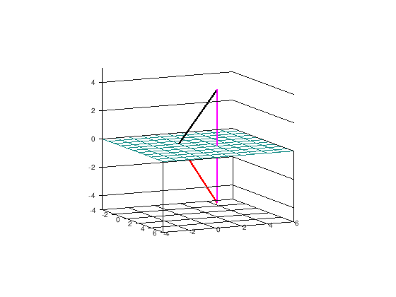

```matlab
graphics_toolkit ("gnuplot");
set(gcf,'Visible','on')
n=11;
tx = ty = linspace (-4, 6, n)';
tx;
[xx, yy] = meshgrid (tx, ty);
tz = zeros(n,n);
mesh (tx, ty, tz);
axis("equal")
view([65,10])
line([0,2],[0,2],[0,4],"linewidth",4,"color","k")
x=[2 ;2 ; 4 ];
A=[1 0 0 ;0 1 0; 0 0 -1];
v=A*x;
vec=v;
line([0,vec(1)],[0,vec(2)],[0,vec(3)],"linewidth",4,"color","r")
line([x(1),vec(1)],[x(2),vec(2)],[x(3),vec(3)],"linewidth",4,"color","m");
```

What would be the standard matrices for reflections about the xz and yz planes?

### Orthogonal Projections

#### On the x-axis (or onto the..)

$$ T_a: \mathbb{R}^2 \rightarrow \mathbb{R}^2 \mbox{ given by } T_a(x_1,x_2)=(x_1,\ 0)\\ \\ A=\begin{bmatrix} 1 & 0\\ 0 & 0 \end{bmatrix} $$

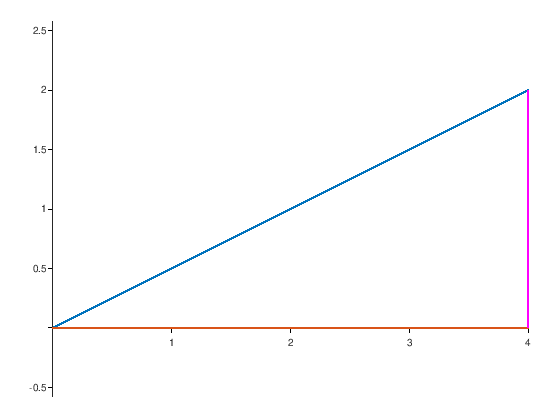

```matlab
set(gca, "xaxislocation", "origin")
set(gca, "yaxislocation", "origin")
axis("equal")
x=[4 ;2 ];
A=[1 0; 0 0];
v=A*x;
vec=x;
line([0,vec(1)],[0,vec(2)],"linewidth",4);
vec=v;
line([0,vec(1)],[0,vec(2)],"linewidth",4);
line([x(1),vec(1)],[x(2),vec(2)],"linewidth",4,"color","m");
```

#### On the y-axis

$$ T_a: \mathbb{R}^2 \rightarrow \mathbb{R}^2 \mbox{ given by } T_a(x_1,x_2)=(0, x_2)\\ \\ A=\begin{bmatrix} 0 & 0\\ 0 & 1 \end{bmatrix} $$

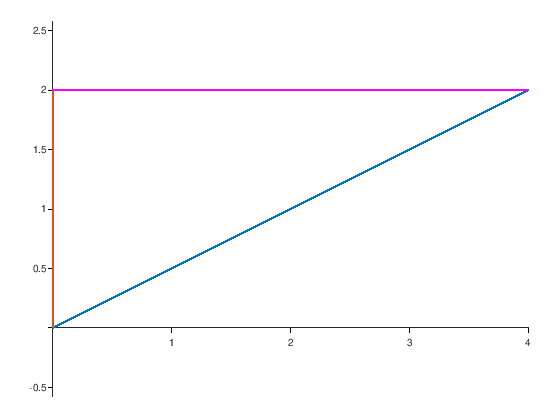

```matlab
set(gca, "xaxislocation", "origin")
set(gca, "yaxislocation", "origin")
axis("equal")
x=[4 ;2 ];
A=[0 0; 0 1];
v=A*x;
vec=x;
line([0,vec(1)],[0,vec(2)],"linewidth",4);
vec=v;
line([0,vec(1)],[0,vec(2)],"linewidth",4);
line([x(1),vec(1)],[x(2),vec(2)],"linewidth",4,"color","m");
```

#### On the zx plane

$$ T_a: \mathbb{R}^3 \rightarrow \mathbb{R}^3 \mbox{ given by } T_a(x_1,x_2,x_3)=(x_1,0,x_3)\\ \\ A=\begin{bmatrix} 1 & 0 & 0\\ 0 & 0 & 0\\ 0 & 0 & 1 \end{bmatrix} $$

E.G. $x=(2,4,2)$

What would be the standard matrices for projection onto the xy and yz planes?

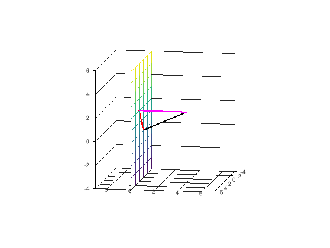

```matlab
graphics_toolkit ("gnuplot");
set(gcf,'Visible','on')
n=11;
tx = linspace (-4, 6, n)';
ty=zeros(n,1);
tz = repmat(tx,1,n);
mesh (tx, ty, tz);
axis("equal")
view([100,10])
line([0,2],[0,4],[0,2],"linewidth",4,"color","k")
x=[2 ;4 ; 2 ];
A=[1 0 0 ;0 0 0; 0 0 1];
v=A*x;
vec=v;
line([0,vec(1)],[0,vec(2)],[0,vec(3)],"linewidth",4,"color","r")
line([x(1),vec(1)],[x(2),vec(2)],[x(3),vec(3)],"linewidth",4,"color","m");
```

### A General Technique For Finding $A$

Let $e_1, e_2, \ldots$ be the standard unit vectors in $\mathbb{R}^n$, NB. as column vectors.

Suppose $A$ is the require standard matrix of the transformation.

Then we get:

$$ T_A(e_1)=Ae_1, \quad T_A(e_2)=Ae_2,\quad \ldots ,\quad T_A(e_n)=Ae_n. $$

Now, $Ae_j$ simply gives column $j$ of the matrix $A$, so we can write:

$$ A=[T_A(e_1)\ |\ T_A(e_2)\ |\ \ldots\ |\ T_A(e_n)] $$

Therefore, one method to find $A$ is to (a) find the image of the standard basis vectors and (b) put these into columns of a matrix which will be $A$.

Example 7.3: Use this technique to find $A$ for the following transformations:

1. Orthogonal projection on the xy plane.
2. About the $y=x$ line.
3. $ T_a: \mathbb{R}^3 \rightarrow \mathbb{R}^2 \mbox{ given by } T_a(x_1,x_2,x_3)=(x_1+x_2,\ x_2+x_3) .$

### Rotation

#### Anti-clockwise rotations in $\mathbb{R}^2$

Rotate a vector by $\theta$ degrees (or radians if you prefer) in an anticlockwise direction. Let the positive $x$-axis represent $0^\circ$.

$$ T_a: \mathbb{R}^2 \rightarrow \mathbb{R}^2 \mbox{ given by } T_a(x_1,x_2)=(x_1 \cos\theta-x_2\sin\theta, x_1 \sin\theta+x_2\cos\theta )\\ \\ A=\begin{bmatrix} \cos\theta &-\sin\theta\\ \sin\theta & \cos\theta \end{bmatrix} $$

Where do these come from?

For example: Let $e_1=(1,0)$ and $e_2=(0,1)$.

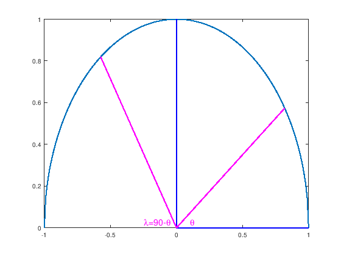

```matlab
graphics_toolkit ("fltk");
 set(gcf,'Visible','on')
x=-1:.01:1;
plot(x,sqrt(1-x.^2),"linewidth", 1);
line([0,1],[0,0],"linewidth", 1,"color","b","linestyle","-");
line([0,0],[0,1],"linewidth", 1,"color","b","linestyle","-");
text(.1,.03,'\fontsize{14}\theta',"color","m");
text(-.25,.03,'\fontsize{14}\lambda=90-\theta',"color","m");
theta=35*pi/180;
line([0,cos(theta)],[0,sin(theta)],"linewidth", 1,"color","m");
line([0,-sin(theta)],[0,cos(theta)],"linewidth", 1,"color","m");
```

Recall the following relevant results from trigonometry:

$$ \sin \theta = \frac{O}{H} \qquad \cos\theta = \frac{A}{H}\qquad -\cos(90-\theta)=-\sin\theta \qquad \sin(90-\theta) = \cos\theta $$

If rotations are required in the clockwise direction, just use $-\theta$.

Rotations are also done in 3D - details omitted but see the textbooks such as A&R chapter 4.

### Dilations and Contractions

In $\mathbb{R}^2$ and $\mathbb{R}^3$ these are:

$$ A=\begin{bmatrix} k & 0\\ 0 & k \end{bmatrix} \qquad A=\begin{bmatrix} k & 0 & 0\\ 0 & k & 0\\ 0 & 0 & k \end{bmatrix} $$

Clearly, $k>1$ is a dilation and $k<1$ is a contraction.

### Expansions and Compressions

These are where only one of the coordinates is multiplied by $k$:

$$ A=\begin{bmatrix} 1 & 0\\ 0 & k \end{bmatrix}, \ A=\begin{bmatrix} k & 0\\ 0 & 1 \end{bmatrix}$$$$ A=\begin{bmatrix} k & 0 & 0\\ 0 & 1 & 0\\ 0 & 0 & 1 \end{bmatrix}, \ A=\begin{bmatrix} 1 & 0 & 0\\ 0 & k & 0\\ 0 & 0 & 1 \end{bmatrix}, \ A=\begin{bmatrix} 1 & 0 & 0\\ 0 & 1 & 0\\ 0 & 0 & k \end{bmatrix} $$

Examples 7.4

For each of the following, use matrix multiplication to find the transformations indicated.

1. Rotation of $\mathbf x=(2,\ -3)$ by $30^\circ$, $60^\circ$, $120^\circ$, $-45^\circ$, $-360^\circ$. Sketch these rotations.
2. In $\mathbb{R}^3$ the orthogonal projection on the x, y and z axes are defined by the following equations: $T_1(x,y,z)=(x,0,0)$, $T_2(x,y,z)=(0,y,0)$, $T_3(x,y,z)=(0,0,z)$ respectively.
   - Show that these are linear operators and find their standard matrices.
   - Show that if $T:\mathbb{R}^3\rightarrow \mathbb{R}^3$ is an orthogonal projection on one of the coordinate axes, then for every vector $\mathbf x$, the vectors $T(\mathbf x)$ and $\mathbf x - T(\mathbf x)$ are orthogonal.
   - Make a sketch show an example of $\mathbf x$ and $\mathbf x - T(\mathbf x)$ in such a case.

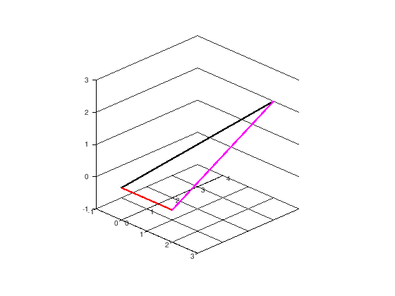

```matlab
graphics_toolkit ("gnuplot");
set(gcf,'Visible','on')
plot3([0,2],[0,4],[0,2],"linewidth",4,"color","k")
axis("equal")
set(gca, "xaxislocation", "origin")
set(gca, "yaxislocation", "origin")
grid on;
view(45,26)
x=[2 ;4 ; 2 ];
A=[1 0 0 ;0 0 0; 0 0 0];
v=A*x;
vec=v;
line([0,vec(1)],[0,vec(2)],[0,vec(3)],"linewidth",4,"color","r")
line([x(1),vec(1)],[x(2),vec(2)],[x(3),vec(3)],"linewidth",4,"color","m");
```

## Compositions of transforms

A number of transform may be done in sequence.

Imagine a matrix transform from $T_A: \mathbb{R}^n\rightarrow \mathbb{R}^k$ and a second follow-on transform $T_B: \mathbb{R}^k\rightarrow \mathbb{R}^m$.

This double transform from $\mathbb{R}^n \rightarrow \mathbb{R}^m$ is called composition of $T_B$ with $T_A$ and can be written:

$$ \left(T_B \circ T_A\right)(\mathbf x) \quad \mbox{ or } T_B\left(T_A(\mathbf x)\right) $$

In terms of the standard matrices we can combine them. Let $A$ be the standard matrix for $T_A$ and $B$ the corresponding standard matrix for $T_B$, then:

$$\left(T_B \circ T_A\right)(\mathbf x) = BA\mathbf x$$

We can keep going, e.g.

$$\left(T_C \circ T_B \circ T_A\right)(\mathbf x) = CBA\mathbf x$$

Note however, that in general $BA\mathbf x \neq AB\mathbf x$, so the order is important and we can say that:

$$ \left(T_B \circ T_A\right)(\mathbf x) \neq \left(T_A \circ T_B\right)(\mathbf x) $$

at least in general.

Examples: 7.5

1. Find the standard matrix for the transformation that first reflects a vector in $\mathbb{R}^2$ about the y-axis and then projects the vector orthogonally on the x-axis. Get the result for the vector $(-2,3)$. Sketch this using software or otherwise.
2. Find the standard matrix for the transformation that first projects a vector in $\mathbb{R}^2$ orthogonally on the y-axis and then reflects the vector about the y-axis. Get the result for the vector $(-2,3)$. Sketch this using software or otherwise.
1. Find the standard matrix for the transformation that (a) first reflect a vector about the $y=x$ line, then (b) rotates the vector by $90^\circ$ and (c) finally projects the vector orthogonally on the x-axis. Perform this transformation on the vector $(2, 7)$. Sketch this using software or otherwise.
2. What would be result have been, if the transformation in part 3 has been done in the order (b), then (a), then (c)?
3. Find the standard matrix for the transformation that operates on a vector in $\mathbb{R}^3$ to first (a) dilates the vector by a factor of 2, then (b) reflects the vector about the yz-plane and finally (c) projects the vector orthogonally on the xz plane. Apply this transformation to the vector (2,1,4).

## One to One transformations

A transformation $T_a: \mathbb{R}^n \rightarrow \mathbb{R}^m $is said to be one-to-one if for each distinct vector $x$ in $\mathbb{R}^n$, its image under $T_a$, i.e. $Ax=b$ is a distinct vector $b$ in the $\mathbb{R}^m$.

Another way of defining this is: $$ T(\mathbf{u})=T(\mathbf{v})\quad \Rightarrow \mathbf{u}=\mathbf{v} $$

A consequence of this, is that the nullspace of standard matrix must be only the zero vector for the transformation to be one-to-one.

### Particular case where $m=n$.

In the case of a square standard matrix we can also define the one-to-one case as follows:

- The transformation (operator) will be one-to-one where $A$ is any of the following:
  - invertible,
  - has a pivot in each column,
  - has a null space of dimension zero,
  - has a non-zero determinant.

In such a case, it can be required to define and find the reverse transformation. This is given by $A^{-1}$ as: $$ T_A: Ax=b \qquad T_{A^{-1}} = A^{-1}b=x $$

Examples 7.6

1. Let: $ T_a: \mathbb{R}^2 \rightarrow \mathbb{R}^2$ given by $T_a(x_1,x_2)=(2x_1+x_2,\ 3x_1+4x_2)$
- Find the standard matrix $A$ and determine if $T_a$ is a one-to-one operator.
- If it is, find the standard matrix for $T^{-1}$, i.e. the inverse operator and and hence write down the defining equations for $T^{−1}$.
- Applying this, find the vector $x$ (i.e. the preimage) for vector $b=(8,17)$
1. Let: $$ T_a: \mathbb{R}^2 \rightarrow \mathbb{R}^2 \mbox{ given by } T_a(x_1,x_2)=(3x_1+2x_2,\ 6x_1+4x_2) $$
- Find the standard matrix $A$ and determine if $T_a$ is a one-to-one operator.
- If it is, find the standard matrix for $T^{-1}$, i.e. the inverse operator and and hence write down the defining equations for $T^{−1}$.
- Applying this, find the vector $x$ (i.e. the preimage) for vector $b=(3,2)$
1. Let $ T_a: \mathbb{R}^3 \rightarrow \mathbb{R}^3$ given by $T_a(x_1,x_2)=(x_1+2x_2-2x_3,\ 2x_1+x_2+x_3,4x_2-x_3)$.
- Find the standard matrix $A$ and determine if $T_a$ is a one-to-one operator.
- If it is, find the standard matrix for $T^{-1}$, i.e. the inverse operator and and hence write down the defining equations for $T^{−1}$.
- Applying this, find the vector $x$ (i.e. the preimage) for vector $b=(1,2,3)$